# Data-driven Methods for Formulating Differential Equations

Alastair Clarke

14 April 2019

### Langevin Equation

The following Ordinary Differential Equation (ODE) can describe the deterministic and stochastic processes of a non-linear, complex system:
$$\begin{equation}
\frac{d}{dt}\mathbf{X}(t) = \mathbf{g}(\mathbf{X}(t), t) + \mathbf{h}(\mathbf{X}(t), t)\eta(t)
\end{equation}$$
where $\mathbf{g}$ represent the deterministic part and $\eta$ the stochastic part. $\mathbf{X}(t)$ is a time-dependent $d$-dimensional, stochastic vector and $\eta$ is Gaussian, white noise, satisfying:

$$\begin{equation}
\langle \eta(t) \rangle = 0
\end{equation}$$
and:
$$\begin{equation}
\langle \eta(t)\eta(t') \rangle = \delta(t-t')
\end{equation}$$
Consider the simpler one-dimensional Langevin equation generating a Brownian motion of a highly-damped particle in the potential field $U(x)$ (Deco et al. 2009):

$$\begin{equation}
\frac{dx}{dt} = \frac{dU(x)}{dx} + \sqrt{2D}\eta(t)
\end{equation}$$
where $D$ is a noise intensity constant. The probability density function of $x$ is a solution to the Fokker-Planck equation.

### Linear Growth

The following equation is a simple linear growth model:
$$\begin{equation}
x_{t+1} = rx_t + b
\end{equation}$$
where $x_t$ is the population at time $t$, $r$ is the growth rate and $b$ is a constant. Such a system can adopt one of three states:

1. Long-term, steady-state solution (fixed point);
2. Explosively unstable solution, or;
3. Periodic dynamics.

Below are six time series plots, showing how $x_t$ can evolve for six different values of $r$ ranging from -2 to +2. In each case, $x(t=1) = 0.1$ and $b = 0$.

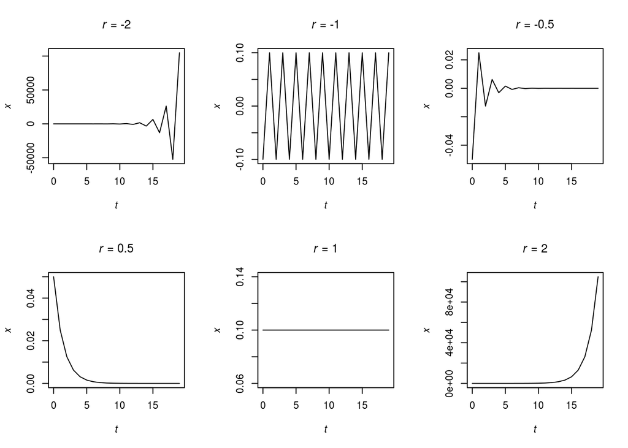

That is a purely deterministic system. Imagine now $b$ is a stochastic process that randomly takes a value of -1 or 1 at each time-step. When $r = -2$, the evolution of $x$ does not change. When $r = -1$, the evolution looks similar to the cyclic behaviour of the deterministic system but the amplitude varies randomly. For $-0.5 < r < 1$, the evolution looks drastically different and alot noisier. When $r = 2$, the evolution is still explosive but negative. This is because the initial value of $b$ is -1. This is an example of how adding noise to a deterministic system can make it sensitive to its initial conditions. If $b(t=1) = +1$, the system would have exploded positively.

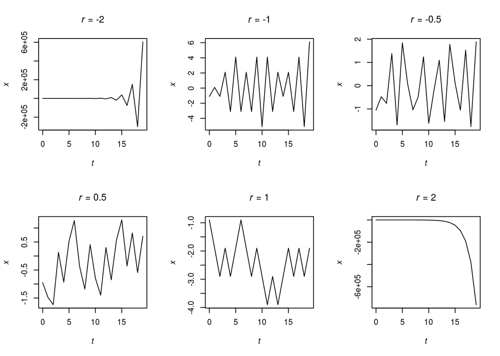

The sign of $b$ and its relative magnitude with respect to $rx_{t}$ determines the evolution of $x$. The following Stochastic Ordinary Differential Equation (SODE):

$$\begin{equation}
\frac{dx}{dt} = rx + b(t)
\end{equation}$$
can be written in difference form:
$$\begin{equation}
x_{t+1} = (r+1)x_t + b_t
\end{equation}$$
with a unit time-step. This is said to be an Orstein-Uhlenbeck process if $b(t)$ is Gaussian noise and $r < -1$, which describes a particle subjected to random velocity impulses that lead to random changes to its position and a restoring force that tends to bring it back to its origin.

If we solve the SODE for $x(0) = -b(0)/r$, $b(0)=0$ and $r = -1.1$, the evolution looks like:

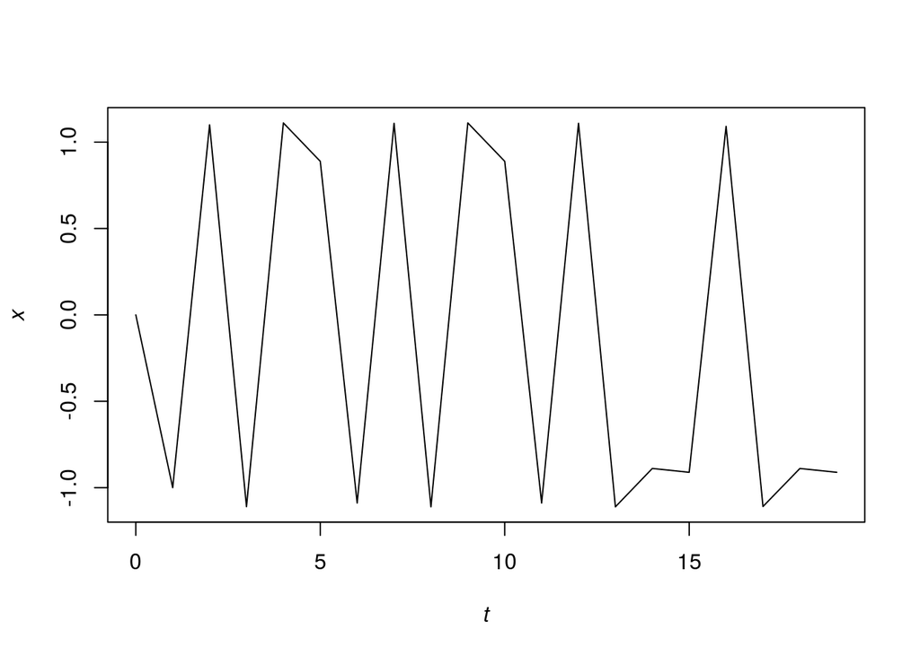

Deco, Gustavo, Daniel Marti, Anders Ledberg, Ramon Reig, and Maria V. Sanchez Vives. 2009. “Effective Reduced Diffusion-Models: A Data Driven Approach to the Analysis of Neuronal Dynamics.” *PLoS Computational Biology*. http://link.galegroup.com/apps/doc/A216182198/AONE?sid=googlescholar.